# Analysis of COVID-19 Data

Domenico Guadalupi

2024-04-17

## Introduction

This report conducts a comprehensive analysis of COVID-19 data sourced from the John Hopkins University repository. The dataset encompasses information on confirmed cases and fatalities from COVID-19 at both global and US levels. Our primary objective is to discern prevailing trends in COVID-19 cases and mortality rates. To contextualize the data spatially, we integrate it with the us_states and world datasets available in the spData library. Leveraging information regarding the GDP per capita embedded within these datasets, we explore the correlation between mortality rates and GDP per capita. This comprehensive approach allows us to get deeper insights into the dynamics of COVID-19’s impact across different geographical regions.

## Data Preparation

We started by retrieving the data from the John Hopkins University repository and performed necessary cleansing.

```r
url_in <- 'https://raw.githubusercontent.com/CSSEGISandData/COVID-19/master/csse_covid_19_data/csse_covid_19_time_series/'

file_names <- c('time_series_covid19_confirmed_US.csv',
                'time_series_covid19_confirmed_global.csv',
                'time_series_covid19_deaths_US.csv',
                'time_series_covid19_deaths_global.csv')
urls <- paste0(url_in, file_names)

confirmed_US = read_csv(urls[1])
confirmed_global = read_csv(urls[2])
deaths_US = read_csv(urls[3])
deaths_global = read_csv(urls[4])

confirmed_US <- confirmed_US %>%
  pivot_longer(cols = seq(12, ncol(confirmed_US)),
               names_to = 'date',
               values_to = 'cases')

confirmed_global <- confirmed_global %>%
  pivot_longer(cols = seq(5, ncol(confirmed_global)),
               names_to = 'date',
               values_to = 'cases')

deaths_US <- deaths_US %>%
  pivot_longer(cols = seq(13, ncol(deaths_US)),
               names_to = 'date',
               values_to = 'deaths')

deaths_global <- deaths_global %>%
  pivot_longer(cols = seq(5, ncol(deaths_global)),
               names_to = 'date',
               values_to = 'deaths')
```

## US Data

We merged the US data with spatial data from the spData library and calculated cumulative values for cases and deaths for each state. Subsequently, we derived mortality as the ratio of deaths to cases.

```r
data('us_states')
us_states_sf <- st_as_sf(us_states)

US <- confirmed_US %>%
  full_join(deaths_US %>%
              select(Admin2,
                     Province_State,
                     Country_Region,
                     date,
                     deaths)) %>%
  group_by(Province_State,date) %>%
  summarise(cases = sum(cases),
            deaths=sum(deaths),
            .groups = 'keep') %>%
  filter(cases>0) %>%
  mutate(mortality=deaths/cases) %>%
  ungroup %>%
    group_by(Province_State) %>%
    summarize(deaths=max(deaths),
            cases=max(cases),
            mortality=deaths/cases,
            .groups = 'keep') %>%
  left_join(us_states_sf %>% select(c(NAME)),
            by=join_by(Province_State==NAME)) %>%
  st_sf
```

WWe initiated the analysis by examining trends in COVID-19 cases and deaths across the United States. The following plots illustrate the total number of cases and deaths in each state, highlighting those with the highest numbers. Additionally, we scrutinized mortality rates across states to identify regions with elevated mortality rates.

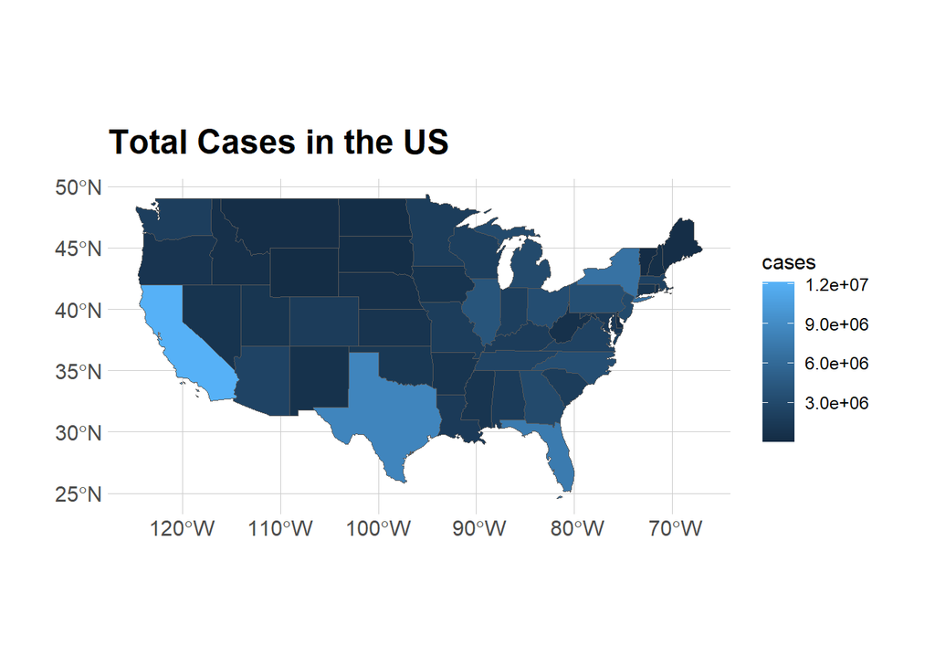

```r
ggplot(US)+
  geom_sf(aes(fill=cases))+
  ggtitle('Total Cases in the US')
```

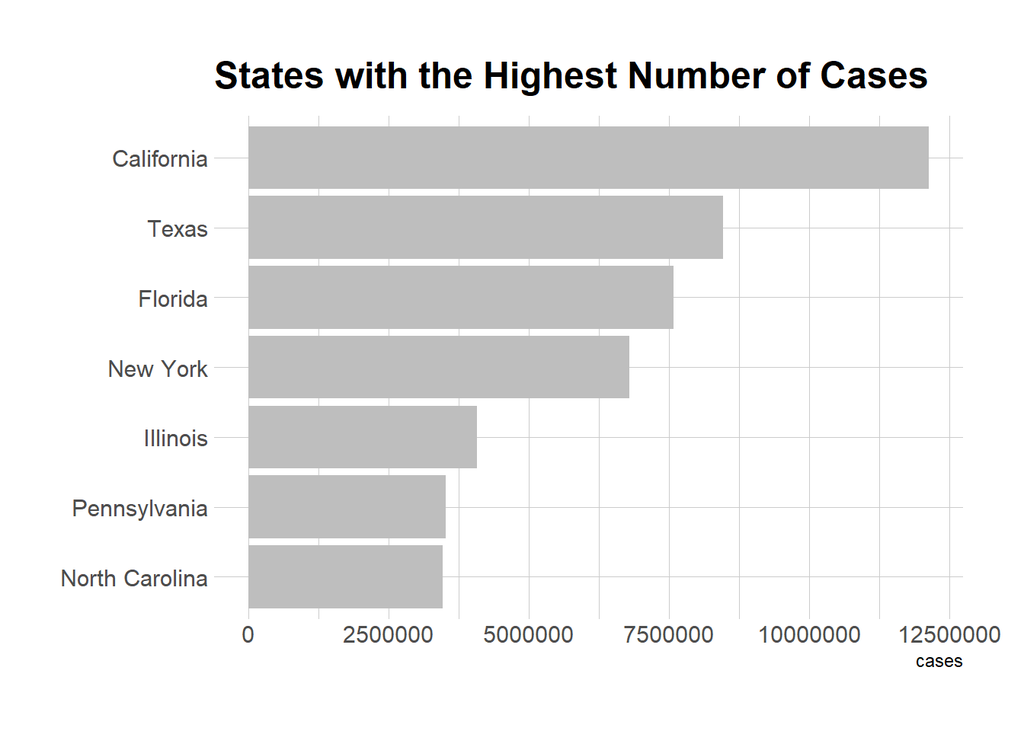

```r
ggplot(data = US %>% arrange(desc(cases)) %>% .[1:7,]) +
  geom_col(aes(y = reorder(Province_State, -desc(cases)), x = cases), fill = 'grey')+
  labs(y=NULL)+
  ggtitle('States with the Highest Number of Cases')
```

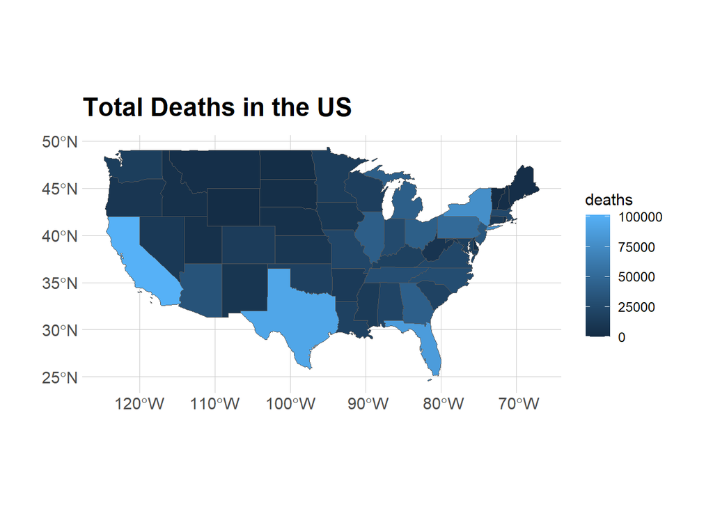

```r
#total deaths  by stae

ggplot(US)+
  geom_sf(aes(fill=deaths))+
  ggtitle('Total Deaths in the US')
```

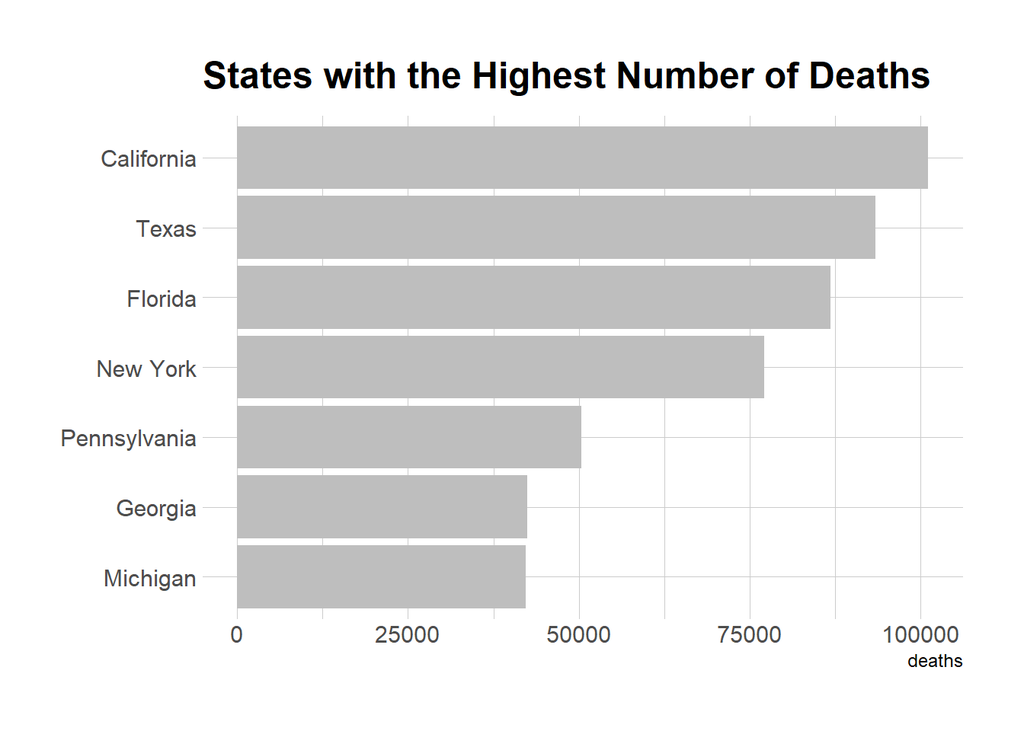

```r
ggplot(data = US %>% arrange(desc(deaths)) %>% .[1:7,]) +
  geom_col(aes(y = reorder(Province_State, -desc(deaths)), x = deaths), fill = 'grey') +
  labs(y=NULL)+
  ggtitle('States with the Highest Number of Deaths')
```

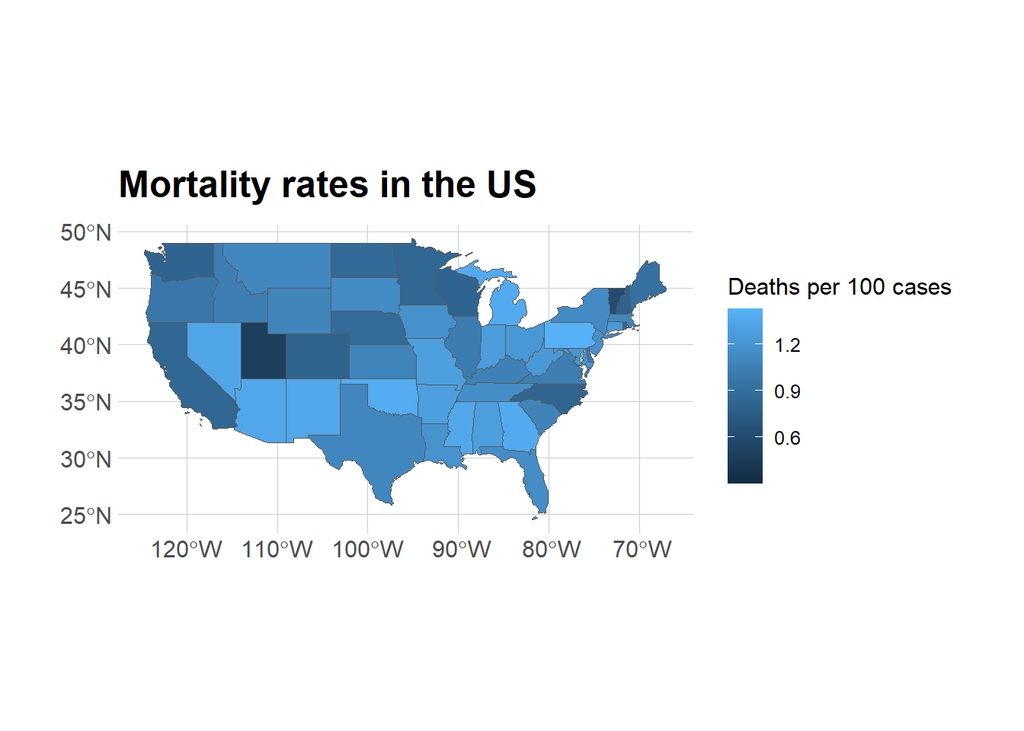

```r
ggplot(US %>% filter(cases>1000))+
  geom_sf(aes(fill=100*mortality))+
  labs(title = 'Mortality rates in the US',
       fill='Deaths per 100 cases')
```

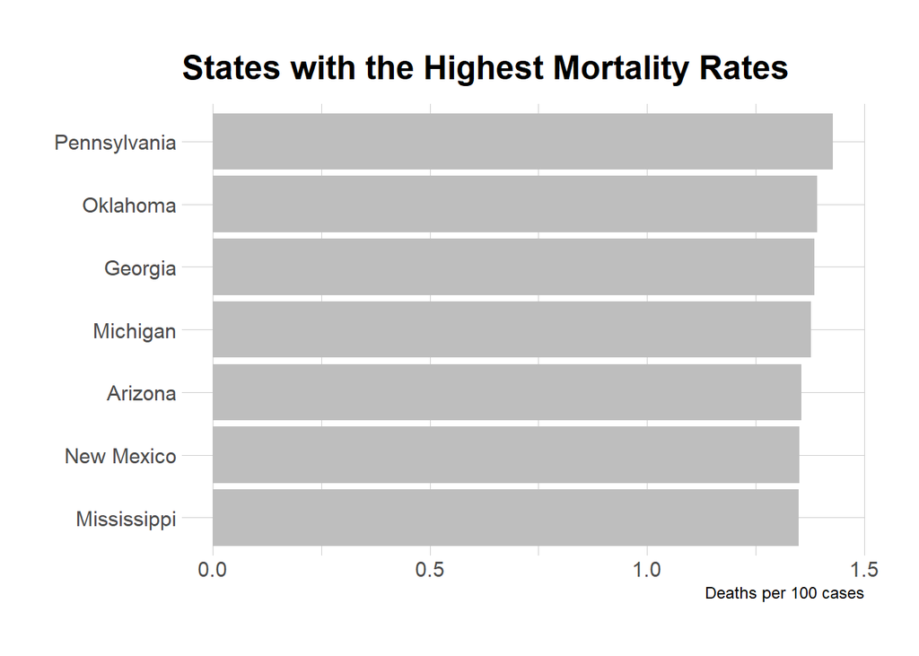

```r
ggplot(data = US %>% filter(cases>1000) %>% arrange(desc(mortality)) %>% .[1:7,]) +
  geom_col(aes(y = reorder(Province_State, -desc(mortality)), x = mortality*100), fill = 'grey')+
  labs(title = 'States with the Highest Mortality Rates',
       x = 'Deaths per 100 cases',
       y = NULL)
```

## Global Data

We extended our analysis globally by merging the global data with spatial data from the spData library and calculating cumulative values for cases and deaths for each nation. Similar to the US analysis, we derived mortality as the ratio of deaths to cases.

```r
data('world')
world_sf <- st_as_sf(world)

world_sf$name_long[world_sf$name_long=="Taiwan"] <- "Taiwan*"
world_sf$name_long[world_sf$name_long=="United States"] <- "US"
world_sf$name_long[world_sf$name_long=="Russian Federation"] <- "Russia"
world_sf$name_long[world_sf$name_long=="Democratic Republic of the Congo"] <- "Congo (Kinshasa)"
world_sf$name_long[world_sf$name_long=="Republic of the Congo"] <- "Congo (Brazzaville)"
world_sf$name_long[world_sf$name_long=="Côte d'Ivoire"] <- "Cote d'Ivoire"
world_sf$name_long[world_sf$name_long=="The Gambia"] <- "Gambia"
world_sf$name_long[world_sf$name_long=="Dem. Rep. Korea"] <- "Korea, North"
world_sf$name_long[world_sf$name_long=="Republic of Korea"] <- "Korea, South"
world_sf$name_long[world_sf$name_long=="Czech Republic"] <- "Czechia"
world_sf$name_long[world_sf$name_long=="Brunei Darussalam"] <- "Brunei"
world_sf$name_long[world_sf$name_long=="Lao PDR"] <- "Laos"
world_sf$name_long[world_sf$name_long=="Palestine"] <- "West Bank and Gaza"


global <- confirmed_global %>%
  full_join(deaths_global) %>%
  rename(Province_State='Province/State', Country_Region='Country/Region') %>%
  select(-c(Lat,Long)) %>%
  filter(!Country_Region %in% c("Winter Olympics 2022",
                                "Summer Olympics 2020",
                                "Diamond Princess",
                                "MS Zaandam",
                                "Holy See",
                                "Korea, North")#1 only case and 6 deaths registered in North Korea
         ) %>%
  group_by(Country_Region,date) %>%
  summarise(cases = sum(cases), deaths=sum(deaths), .groups = 'keep') %>%
  filter(cases>0) %>%
  ungroup() %>%
  group_by(Country_Region) %>%
  summarize(deaths=max(deaths),
            cases=max(cases),
            mortality=deaths/cases,
            .groups = 'keep') %>%
  left_join(
    world_sf %>% select(c(name_long, gdpPercap)),
    by=join_by(Country_Region==name_long)
  ) %>%
  rename(geometry='geom') %>%
  st_sf()
```

We conducted a global analysis to understand the worldwide impact of COVID-19. Similar to the US analysis, we visualized the total number of cases and deaths in different countries, as well as their mortality rates. This allowed us to identify countries with the highest numbers of cases and deaths, as well as those with the highest mortality rates.

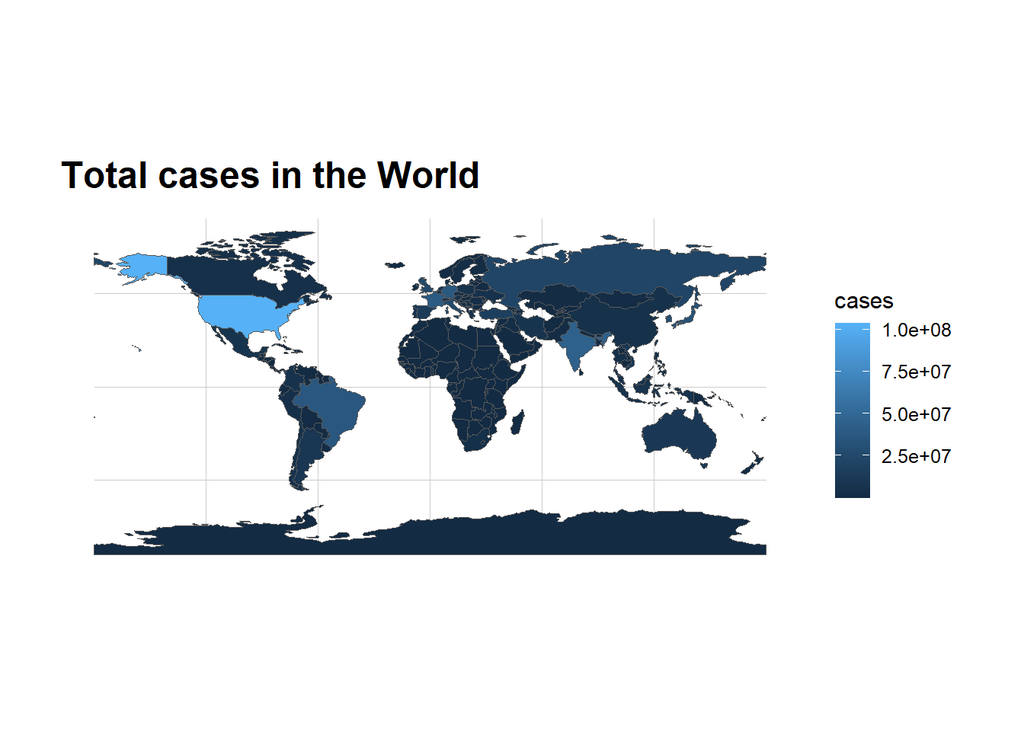

```r
ggplot(global)+
  geom_sf(aes(fill=cases))+
  labs(title='Total cases in the World')
```

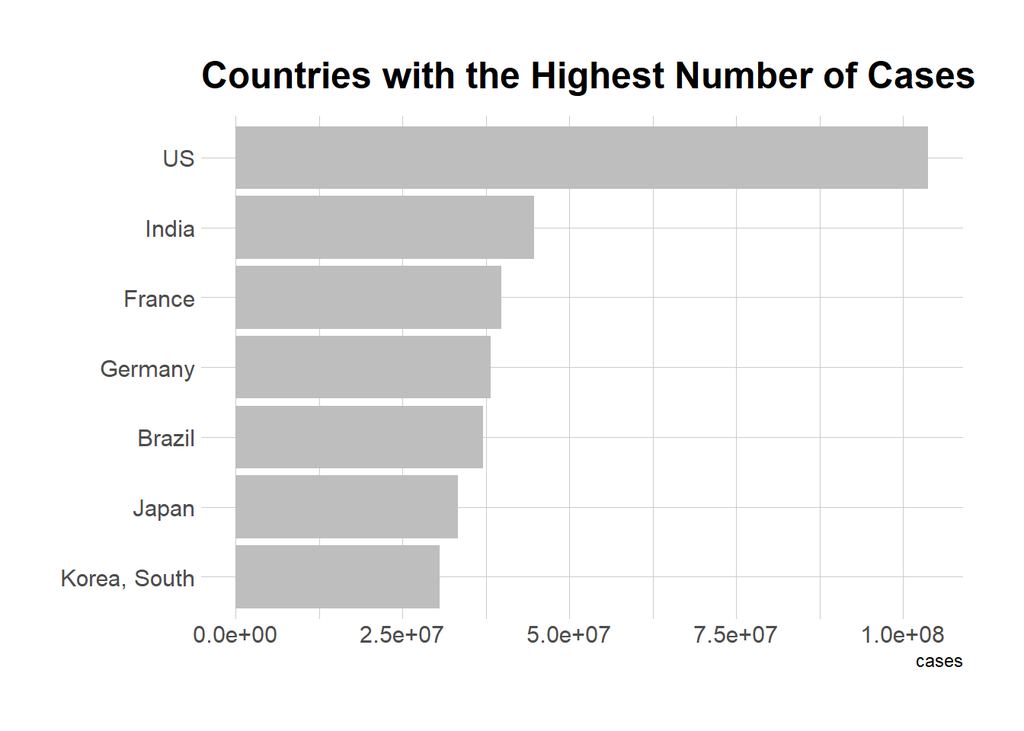

```r
ggplot(data = global %>% arrange(desc(cases)) %>% .[1:7,]) +
  geom_col(aes(y = reorder(Country_Region, -desc(cases)), x = cases), fill='grey')+
  labs(y=NULL,
       title = 'Countries with the Highest Number of Cases')
```

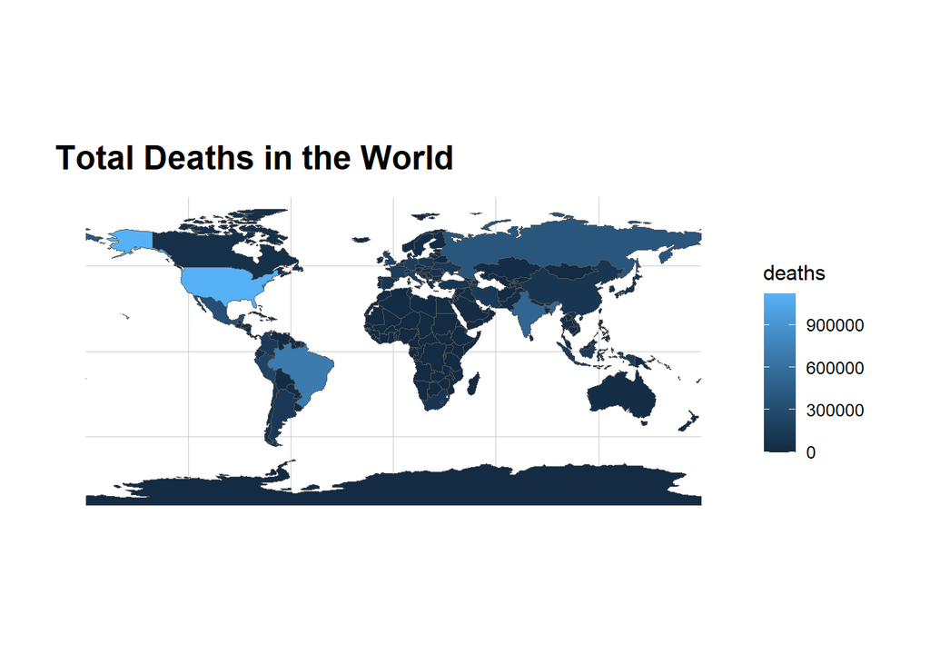

```r
#total deaths  by country
ggplot(global)+
  geom_sf(aes(fill=deaths))+
  labs(title='Total Deaths in the World')
```

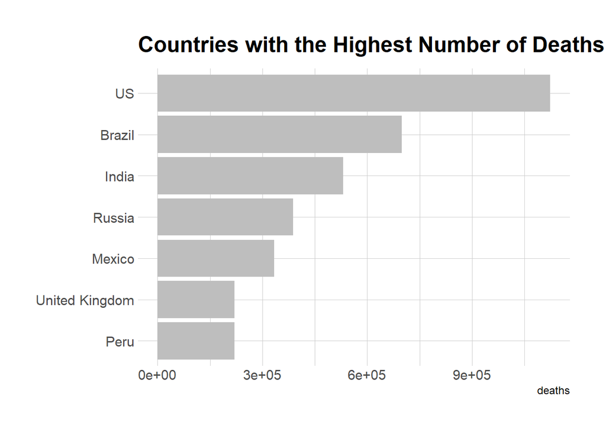

```r
ggplot(data = global %>% arrange(desc(deaths)) %>% .[1:7,]) +
  geom_col(aes(y = reorder(Country_Region, -desc(deaths)), x = deaths), fill='grey')+
  labs(y=NULL,
       title = 'Countries with the Highest Number of Deaths')
```

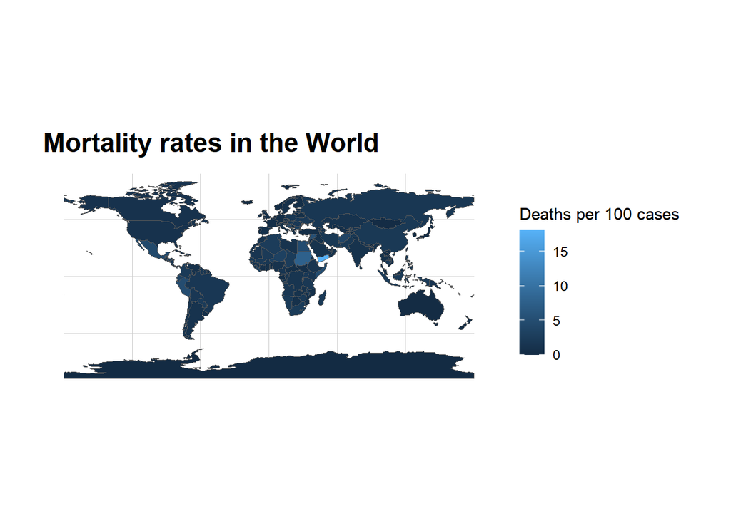

```r
ggplot(global)+
  geom_sf(aes(fill=100*mortality))+
  labs(title = 'Mortality rates in the World',
       fill = 'Deaths per 100 cases')
```

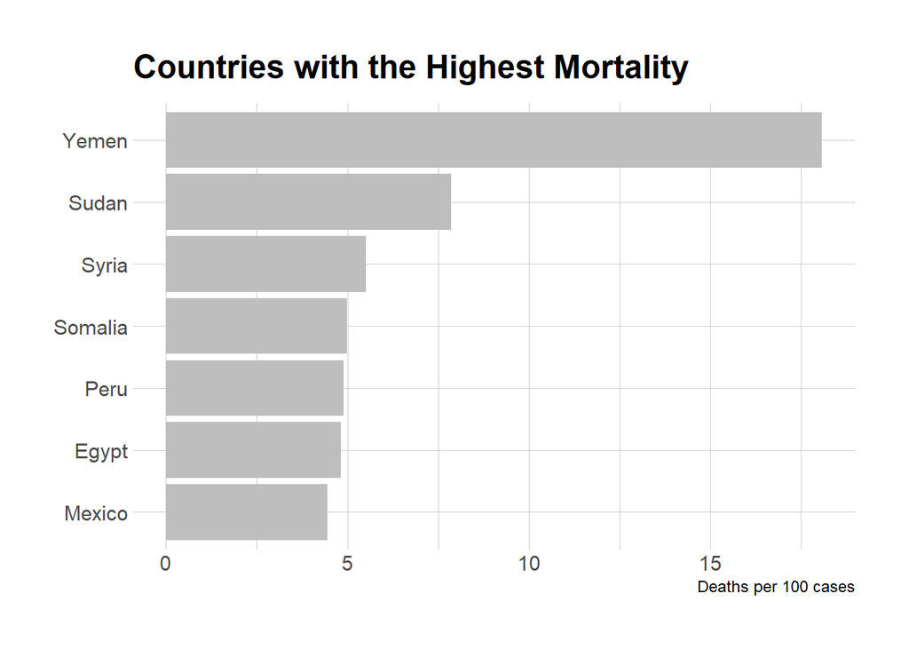

```r
ggplot(data = global %>% arrange(desc(mortality)) %>% .[1:7,]) +
  geom_col(aes(y = reorder(Country_Region, -desc(mortality)), x = mortality*100), fill='grey')+
  labs(x = 'Deaths per 100 cases',
       y=NULL,
       title = 'Countries with the Highest Mortality')
```

## Mortality vs. GDP per Capita

To further explore the factors influencing mortality rates, we investigated the relationship between mortality rates and GDP per capita. Using linear regression analysis, we identified a significant negative correlation between GDP per capita and mortality rates. The model below illustrates this relationship, showing a decreasing trend in mortality rates with increasing GDP per capita.  
The mortality rate for Yemen has been identified as an outlier, and so it has been removed from the analysis to ensure that the linear regression model accurately represents the relationship between GDP per capita and mortality rates for the majority of countries.

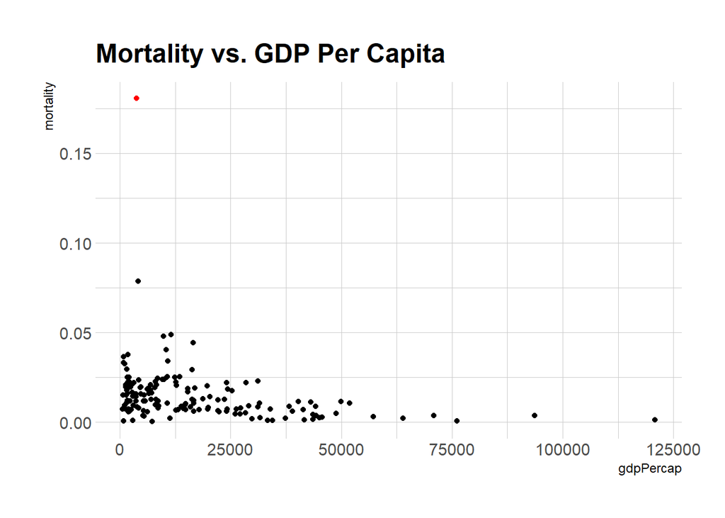

```r
#spot the outlier
ggplot(global)+
  geom_point(aes(x=gdpPercap, y=mortality))+
  geom_point(data = global %>% filter(Country_Region=='Yemen'),aes(x=gdpPercap, y=mortality), color='red')+
  labs(title = 'Mortality vs. GDP Per Capita')
```

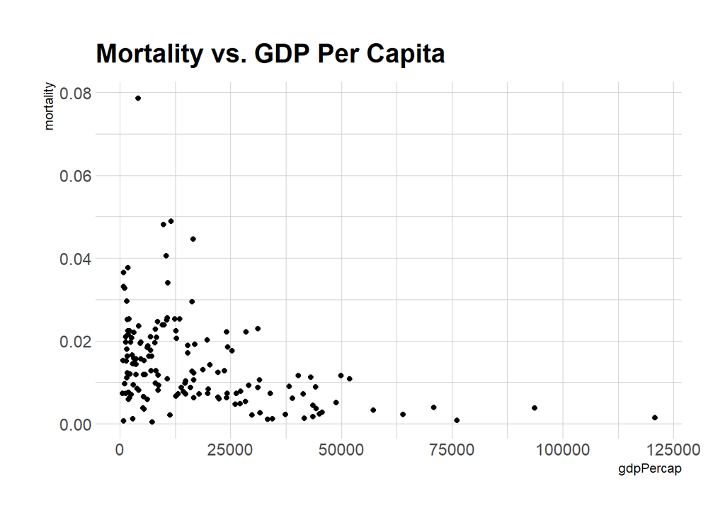

```r
global <- global %>% filter(!is.na(gdpPercap), Country_Region!='Yemen')#Remove the outlier

ggplot(global)+
  geom_point(aes(x=gdpPercap, y=mortality))+
  labs(title = 'Mortality vs. GDP Per Capita')
```

```r
model <- lm(mortality~gdpPercap, data=global)
model %>% summary()
```

```
##
## Call:
## lm(formula = mortality ~ gdpPercap, data = global)
##
## Residuals:
##       Min        1Q    Median        3Q       Max
## -0.017316 -0.006488 -0.001738  0.004533  0.061352
##
## Coefficients:
##               Estimate Std. Error t value Pr(>|t|)
## (Intercept)  1.821e-02  1.111e-03  16.389  < 2e-16 ***
## gdpPercap   -2.292e-07  4.348e-08  -5.271 4.57e-07 ***
## ---
## Signif. codes:  0 '***' 0.001 '**' 0.01 '*' 0.05 '.' 0.1 ' ' 1
##
## Residual standard error: 0.01016 on 152 degrees of freedom
## Multiple R-squared:  0.1546, Adjusted R-squared:  0.149
## F-statistic: 27.79 on 1 and 152 DF,  p-value: 4.571e-07
```

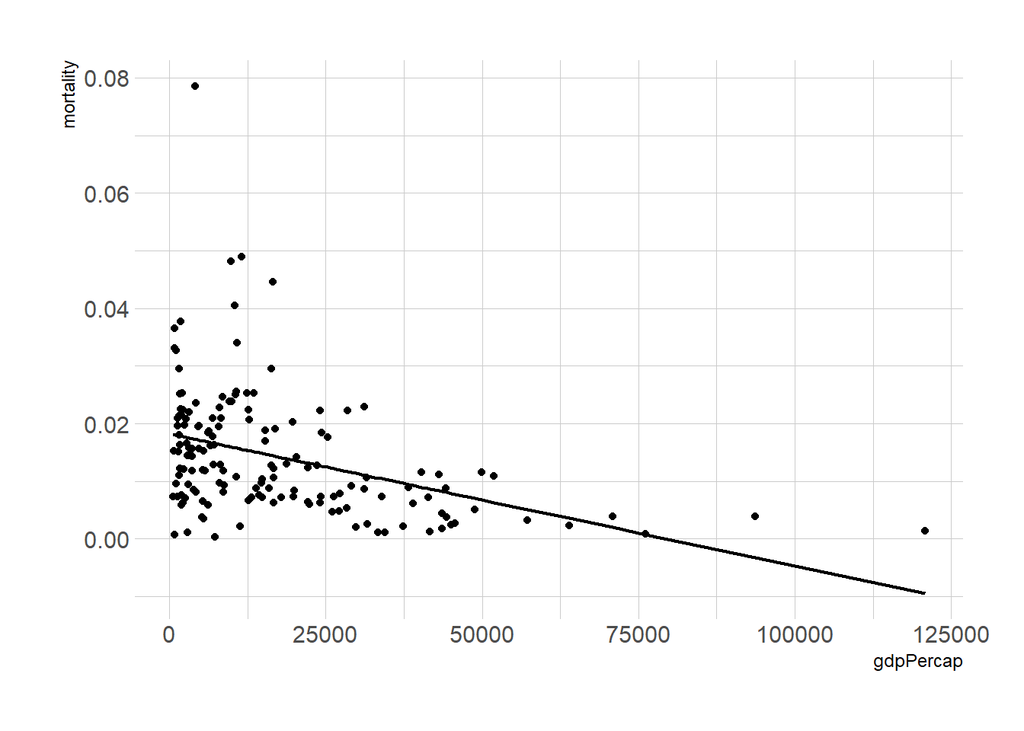

```r
global$pred = predict(model, global)

ggplot(global)+
  geom_point(aes(x=gdpPercap, y=mortality))+
  geom_line(aes(x= gdpPercap, y = pred), size=0.8)
```

## Biases and Limitations

It’s crucial to acknowledge the biases and limitations of this analysis.

- *Data Quality*: One potential source of bias in the analysis is the quality of the COVID-19 data itself. The accuracy and reliability of reported cases and deaths can vary across different regions and countries due to factors such as differences in testing capabilities, reporting protocols, and healthcare infrastructure. For example, regions with limited testing capacity or underreporting may have artificially lower case and death counts, leading to an underestimation of the true impact of the pandemic in those areas. Conversely, regions with more robust testing and reporting mechanisms may appear to have higher case and death counts.
- *Testing Methodologies*: Disparities in testing methodologies can also introduce bias into the data analysis. Variations in testing criteria, availability of testing supplies, and accessibility of testing facilities can influence the number of reported cases and deaths. For instance, regions that prioritize testing for symptomatic individuals or high-risk populations may have higher case counts compared to regions with less widespread testing. Additionally, differences in the accuracy of diagnostic tests and the frequency of testing can affect the reliability of the data.

## Conclusion

In conclusion, this analysis provides valuable insights into the trends and factors influencing COVID-19 mortality rates. By examining the spatial distribution of cases and deaths, as well as the relationship between mortality rates and GDP per capita, we gain a better understanding of the impact of the pandemic. Moving forward, it’s crucial to continue monitoring and analyzing COVID-19 data to inform public health policies and interventions.